# Data Visualization

#### Visualization using ggplot2 library

Before we can plot, we need to load the ggplot2 library first:

```r
library(ggplot2)
# we will need to manipulate data so load dplyr.
library(dplyr)
# load gapminder data we previously used
library(gapminder)
```

#### Practice: scatter plot via ggplot() + geom_point():

Suppose we filter the data from gapminder for data in year 1952. Using this filtered data, we want to create a plot with pop against gdpPercap:

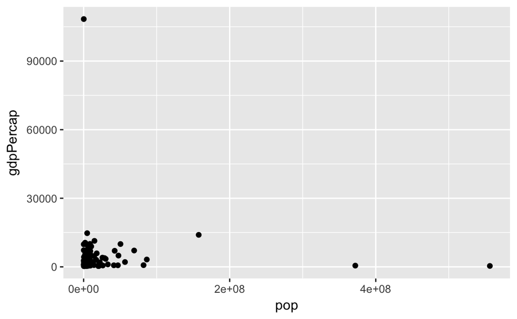

```r
# Filtering data and assigning the results to a variable
gapminder_1952 <- gapminder %>%
  filter(year == 1952)
# Change to put pop on the x-axis and gdpPercap on the y-axis.
# Note:  geom_point() is what plots it like: ggplot() + geom_point()
ggplot(gapminder_1952, aes(x = pop, y = gdpPercap)) +
  geom_point()
```

#### Change axis to log by adding: scale_x_log10()

Using the previously declared and filtered data, we want to create a log-10 x scale for scatter plot with x as population (pop) and y as life expectancy (lifeExp):

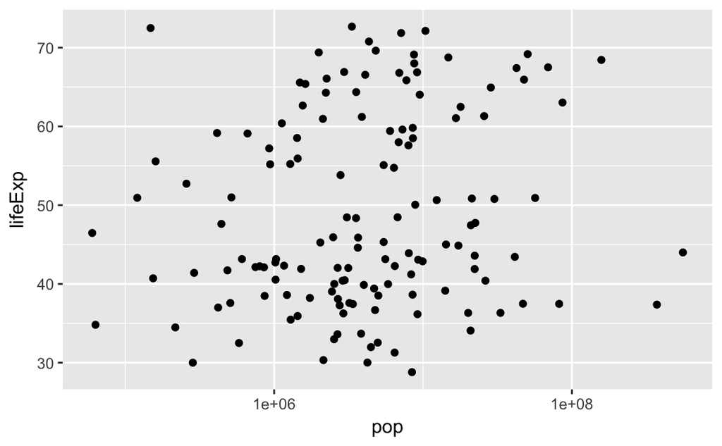

```r
# we previously filtered and declared gapminder_1952
# reminder: regular plotting requires ggplot() + geom_point()
# plotting data with log10 as the primary scale for x-axis:
ggplot(gapminder_1952, aes(pop , lifeExp)) + geom_point() + scale_x_log10()
```

#### Color aesthetic

Adding color is another way to add a 3rd variable in our otherwise x-y scatter point. A simple way to add color to our previous graphs is by passing `color = continent` inside aes() as an argument. While we are plotting population against life expectancy, we can further specify the data with their corresponding continent.

Let’s see what happens to our graph:

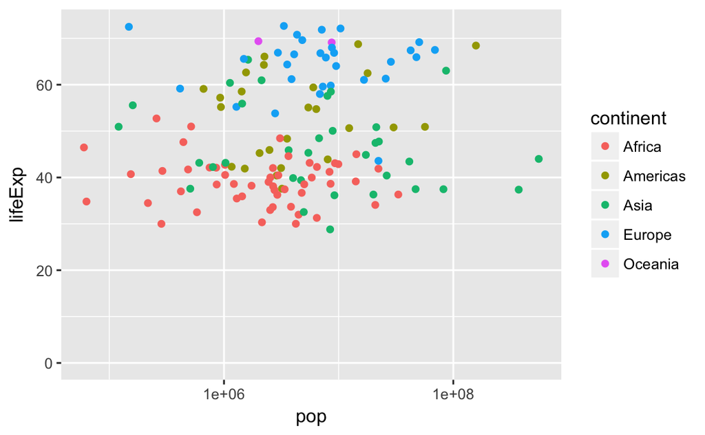

```r
ggplot(gapminder_1952, aes(pop , lifeExp, color = continent)) + geom_point() + scale_x_log10() + expand_limits(y = 0)
```

#### Size aesthetic

Suppose we want the dots to have varying sizes based on a 3rd variable from the data set. We can simply pass the keyword size to the aes() function equal to the 3rd variable name we want to convey:

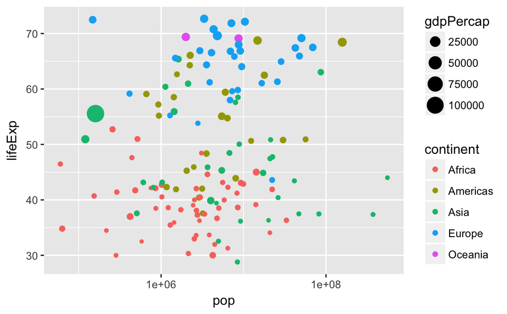

```r
ggplot(gapminder_1952, aes(x = pop, y = lifeExp, color = continent, size = gdpPercap)) +
  geom_point() +
  scale_x_log10()
```

#### Faceting. Splitting by adding facet_wrap(~var)

In the last two codes, data points from various continents were combined in a single scatter plot. Instead of doing it, we can split them into multiple smaller plots by using another variable as filter. Suppose we want to faceting the plots into multiple plots by continent:

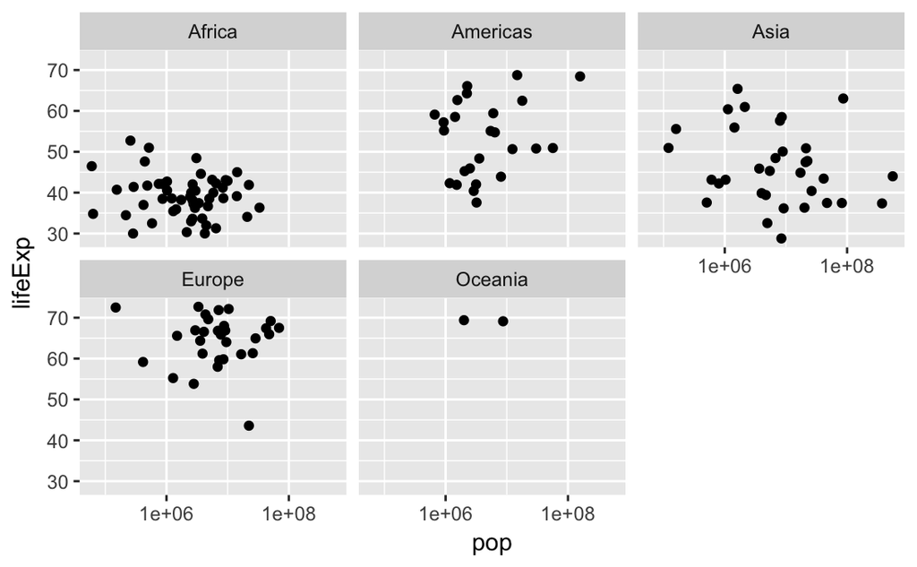

```r
ggplot(gapminder_1952, aes(x = pop, y = lifeExp)) +
  geom_point() +
  scale_x_log10() +
  facet_wrap(~continent)
```